[figure not shown]

# HUMANA-MAYS CASE HEALTHCARE ANALYTICS 2019 CASE COMPETITION

## Predictive Analysis on Long Term Opioid Therapy

### Co-worker: Jiawen Liang, Khanh (Chris) Tran

This Humana-Mays Healthcare Analytics 2019 Case Competition is co-hosted by Texas A&M University Mays Business School and Humana. It is a national-wide case competition exclusive to master students.

After a month of data processing, my teammates [**Jiawen Liang**](https://www.linkedin.com/in/davinaliang/), [**Khanh (Chris) Tran**](https://www.linkedin.com/in/chriskhanhtran/), and I finished the whole predictive process where we predicted the possibility of long-term use of opioid for certain patients based on their medical records. The data was around 1GB large and kinda messy. Fortunately, by utilizing the **LightGBM algorithm**, we got an prediction with **AUC score 0.88**, and **made to TOP 50 Team among 460**.

Below is a rigirous illustration of our data-processing procedure.

Here is the outline of this illustration:

- Case Introduction
- Data Pre-processing
- Exploratory Data Analysis
- Feature Engineering
- Recursive Feature Elimination
- Predictive Modeling
- Result

Hope you enjoy it!

# 1. Case Introduction

[figure not shown]

**Long Term Opioid Therapy (LTOT)** is defined as the continuous use of opioid medication, with 90% of days covered over six months.

Opioid overuse can spell the onset of onerous consequences. The analgesics can slow breathing to dangerous levels and lead to dizziness, nausea, and falls. Thus, out of their concern for patients, Mays Business School and Humana hope the participating groups can identify and rank patients based on the possibility of overusing opioids in order to make a timely intervention.

Based on this requirement, the committee gave us the two datasets. One is for model training, and the other is the holdout dataset on which we should make predictions.

The Training dataset covers four year medical records of 14,000 patients and has six million observation. Each observation provides deatils corresponding to a medical event for the particular memeber. They collected four kinds of medical events data:

- Medical Claim  
  - Medical claims are medical bills submitted to health insurance carriers and other insurance providers for services rendered to patients by providers of care.
- Medical Diagnosis
- Inbound Call  
  - An inbound call is one that a customer initiates to a call center or contact center.
- RX Claim

In order to make a proper prediction, we firstly labelled patients who had LTOT in the trainning dataset. The labelling process is demonstated in the next section.

```python
# Load the important packages for data processing and visualization.
import numpy as np
import pandas as pd
import matplotlib.pyplot as plt
import seaborn as sns
%matplotlib inline
```

```python
from google.colab import drive
drive.mount('/content/drive')
```

```python
trainData = pd.read_csv("/content/drive/My Drive/Humana-May Case Competition/Download/HMAHCC_COMP.csv")
testData = pd.read_csv("/content/drive/My Drive/Humana-May Case Competition/Final Analysis/holdOut_processed.csv")
```

```python
# In order to do model training in the dataset, while make the data processing consistant in both training
  # and holdout dataset, we firstly saved the patients ID into two seperate dataframes.
testID = pd.DataFrame({'id':testData.id.unique()})
trainID = pd.DataFrame({'id':trainData.id.unique()})
```

```python
print(trainID.shape)
print(testID.shape)
```

```
(14000, 1)
(6000, 1)
```

```python
# We only need to care about patient behavior before opoid naive because we are here to make predictions
trainData = trainData[trainData.Days <= 0]
```

```python
fullData = pd.concat([trainData, testData], axis=0)
```

```python
print(fullData.shape)
```

```
(4320622, 20)
```

# 2. Data Preprocessing - Labelling LTOT

To correctly identify and label the event of interest, we subsetted the opioid paid RX claim data. Firstly, we sorted the data by patient id, drug types, and days to avoid overlapping. Then, we identify opioid naïve events of each patient. After that, based on days supplied, we calculated how many days each patient use opioid drugs within 180 days after the last opioid naïve event. This number is reset whenever a patient has a new opioid naive event. Within 180 days after each opioid naive event, if a patient has more than 162 days of opioid supplies, she or he will be labeled as LTOT.

To predict the probability of having LTOT for a patient, we focused on analyzing opioid usage history and each of the main event categories to learn from their past behaviors.

```python
label = pd.read_csv("/content/drive/My Drive/Humana-May Case Competition/Final Analysis/label.csv")
```

```python
label.shape
```

```
(13949, 2)
```

```python
# Merge train data with label
trainDataLabel = trainData.merge(label, on='id')
```

Following up, we did a rigorious exploratory data analysis.

# 3. Exploratory Data Analysis (EDA)

Before doing any predictive modeling, we wanted to explore whether there are significant difference between LTOT and non-LTOT patients in some medical events. Hence we made the following exploratory data analysis:

- Opioid RX Claim
- Other RX Claim
- Inbound Call
- Diagnosis

## 3.1 Main Function Used in EDA

```python
def analyze_attr(attr, df): # the trainning dataset has columns named attributes,
                              #each attribute contain one type of information for a event
    df1 = df[['id', attr, 'LTOP']].copy().groupby(['id', attr]).mean().reset_index() # get the attribute
    df2 = df1.groupby([attr, 'LTOP']).count().reset_index() # divide the attribute into 2 groups
    df2.columns = [attr, 'LTOP', 'count']

    df3 = df2.pivot_table(values='count', index=[attr], columns=['LTOP']).reset_index()
    df3.columns = [attr, 'LTOP_0', 'LTOP_1']
    df3['diff'] = df3.LTOP_1 - df3.LTOP_0
    return df3.sort_values('diff', ascending=False)
```

```python
def plot_attr(attr, df, size):
    df1 = df[['id', attr, 'LTOP']].copy().groupby(['id', attr]).mean().reset_index()
    plt.figure(figsize=(size, 4))
    sns.countplot(x=attr, hue='LTOP', palette="Paired", data=df1)
```

## 3.2 Opioid RX Claim

When labeling LTOT, we realized that the history of opioid usage might be highly correlated with the likelihood of future LTOT. So we decided to discover opioid usage history first. We tried to explore whether LTOT and non-LTOT patients would have different patterns in various attributes provided in the data.

```python
rxClaimPaid = fullData[fullData.event_descr=='RX Claim - Paid'].copy()
 # subset the event category equal to RX claim

opioid = rxClaimPaid[rxClaimPaid.PAY_DAY_SUPPLY_CNT >= 0].copy()
# in the original dataset Pay Day Supply Cnt is the specific column for opioid claim
  # which indicates how many days this patient can use opioid drug.

EDA_opioid = opioid.merge(label,on='id')
```

### 3.2.1 For GPI Drug Class Description

```python
analyze_attr('event_attr1',EDA_opioid).head(5)
```

|  | event_attr1 | LTOP_0 | LTOP_1 | diff |
| --- | --- | --- | --- | --- |
| 0 | OPIOID AGONISTS | 3175 | 4154 | 979 |
| 3 | OPIOID PARTIAL AGONISTS | 34 | 77 | 43 |
| 1 | OPIOID ANTAGONISTS | 9 | 22 | 13 |
| 2 | OPIOID COMBINATIONS | 5953 | 4320 | -1633 |

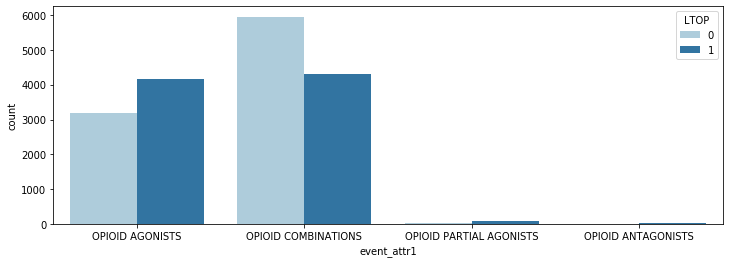

```python
plot_attr('event_attr1',EDA_opioid,12)
```

### 3.2.2 For Drug Brand Name

```python
analyze_attr('event_attr5',EDA_opioid).head(5)
```

|  | event_attr5 | LTOP_0 | LTOP_1 | diff |
| --- | --- | --- | --- | --- |
| 53 | TRAMADOL HCL | 2708.0 | 3177.0 | 469.0 |
| 34 | MORPHINE SULFATE ER | 94.0 | 395.0 | 301.0 |
| 43 | OXYCODONE HCL | 430.0 | 681.0 | 251.0 |
| 19 | FENTANYL | 72.0 | 239.0 | 167.0 |
| 32 | METHADONE HCL | 21.0 | 145.0 | 124.0 |

### 3.2.3 For Specialist Type

```python
analyze_attr('Specialty',EDA_opioid).head(5)
```

|  | Specialty | LTOP_0 | LTOP_1 | diff |
| --- | --- | --- | --- | --- |
| 32 | Family Practice | 1831.0 | 2623.0 | 792.0 |
| 2 | Anesthesiology Pain Medicine | 260.0 | 813.0 | 553.0 |
| 42 | Internal Medicine | 1347.0 | 1849.0 | 502.0 |
| 110 | Physical Medicine & Rehab Pain Medicine | 95.0 | 370.0 | 275.0 |
| 114 | Physical Medicine & Rehabilitation | 176.0 | 432.0 | 256.0 |

### 3.2.4 Opioid Supply at the opioid navie day

*P.S: Opioid Navie means that a patient did not have opioid drug on hand for more than 90 days before today.*

The number of opioid prescriptions and the number of opioid drug supplies are also different between LTOT and non-LTOT patients. Meanwhile, we found a significant difference between LTOT and non-LTOT patients of how many drugs they received at the opioid naive day.

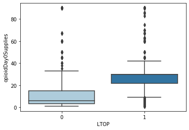

```python
opioidDay0Supplies = EDA_opioid[EDA_opioid.Days==0][['id','PAY_DAY_SUPPLY_CNT','LTOP']].groupby('id').max().reset_index()
opioidDay0Supplies.columns = ['id','opioidDay0Supplies','LTOP']
opioidDay0Supplies.head()
sns.boxplot(x='LTOP',y='opioidDay0Supplies',data=opioidDay0Supplies,palette='Paired')
```

## 3.3 Other RX Claims

In the training dataset, they also provided information about other drug claims. Therefore, we explored them as well.

```python
otherRXClaims = fullData[fullData.event_descr=='RX Claim - Paid'].copy()
 # subset the event category equal to RX claim

otherRX = otherRXClaims[otherRXClaims.Days <= 0].copy()
# in the original dataset Pay Day Supply Cnt is the specific column for opioid claim
  # which indicates how many days this patient can use opioid drug.

EDA_otherRXClaims = otherRX.merge(label,on='id')
```

From our previous analysis, we found out for each attribute the average appearance on LTOT patients and on non-LTOT patients varies. Therefore, we created the following function to capture and visulize those differences.

```python
def getcountdiff(attr,df,name):
    """
    Capture the different between LTOT and non-LTOT of a particular attribute by average for each patient.
    """
    # count the certain appearance of one attribute for an individual and group by there LTOT status.
    df1 = df[['id',attr, 'LTOP','event_attr5']].copy().groupby(['id',attr,'LTOP']).count().reset_index()
    # count the average value for LTOT and non-LTOT group
    df2 =  df1.copy().groupby([attr,'LTOP']).mean().reset_index()
    df2.columns=[attr,'LTOP','count']
    df2.sort_values('count',ascending=False,inplace=True)
    # convert it to a pivot table and calculate the difference
    df3 = df2.pivot(index=attr, columns='LTOP', values='count').reset_index()
    df3.columns=[name,'LTOP_0','LTOP_1']
    df3['diff']=abs(df3['LTOP_0']-df3['LTOP_1'])
    df3.sort_values('diff',ascending=False,inplace=True)
    return df3.head(5)
```

```python
def plotcountdiff(attr,df,name):
    """
    Visualize the difference
    """
    df1 = df[['id',attr, 'LTOP','event_attr5']].copy().groupby(['id',attr,'LTOP']).count().reset_index()
    df2 =  df1.copy().groupby([attr,'LTOP']).mean().reset_index()
    df2.columns=[attr,'LTOP','count']
    df2.sort_values('count',ascending=False,inplace=True)
    df3 = df2.pivot(index=attr, columns='LTOP', values='count').reset_index()
    df3.columns=[name,'LTOP_0','LTOP_1']
    df3['diff']=abs(df3['LTOP_0']-df3['LTOP_1'])
    df3.sort_values('diff',ascending=False,inplace=True)
    df4 = df3.head(5).melt(id_vars=name,value_vars=['LTOP_0','LTOP_1'])
    return sns.barplot(y=name, x='value', hue='variable', data=df4,palette='Paired')
```

### 3.3.1 For GPI Drug Class

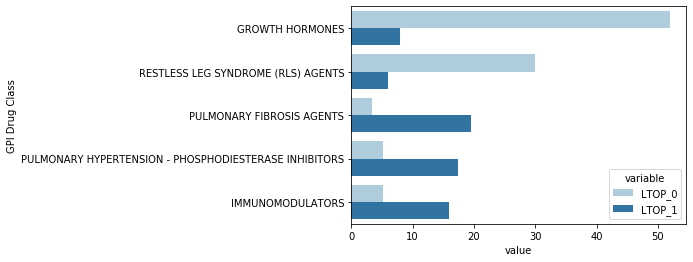

```python
plotcountdiff('event_attr1',EDA_otherRXClaims,'GPI Drug Class')
```

### 3.3.2 For Drug Group

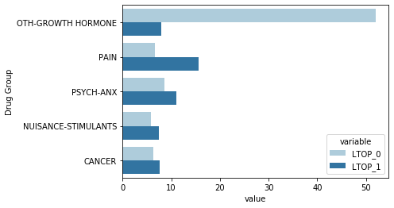

```python
plotcountdiff('event_attr6',EDA_otherRXClaims,'Drug Group')
```

## 3.4 Inbound Call

```python
InboundCall = fullData[(fullData['event_descr']=='Inbound Call by Mbr')|
                (fullData['event_descr']=='Inbound Call by Prov')|
                (fullData['event_descr']=='Inbound Call by Other')].copy()
 # subset the event category equal to RX claim

Inbound = InboundCall[InboundCall.Days <= 0].copy()
# in the original dataset Pay Day Supply Cnt is the specific column for opioid claim
  # which indicates how many days this patient can use opioid drug.

EDA_InboundCall = Inbound.merge(label,on='id')
```

### 3.4.1 Call Inquiry

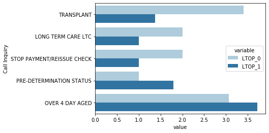

```python
plotcountdiff('event_attr2',EDA_InboundCall,'Call Inquiry')
```

### 3.4.2 Call Disposition

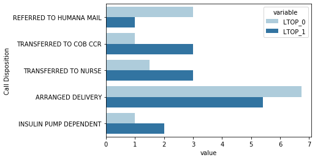

```python
plotcountdiff('event_attr3',EDA_InboundCall,'Call Disposition')
```

## 3.5 Diagnosis

```python
Diagnosis = fullData[(fullData['event_descr']=='Fully Paid Claim')].copy()
 # subset the event category equal to RX claim

Dia = Diagnosis[Diagnosis.Days <= 0].copy()
# in the original dataset Pay Day Supply Cnt is the specific column for opioid claim
  # which indicates how many days this patient can use opioid drug.

EDA_Diagnosis = Dia.merge(label,on='id')
```

### 3.5.1 Diagnosis

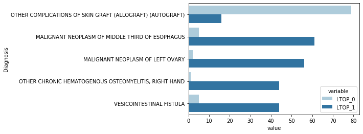

```python
plotcountdiff('event_attr1',EDA_Diagnosis,'Diagnosis')
```

### 3.5.2 Place of Treatment

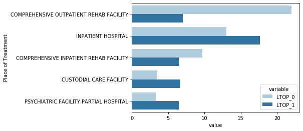

```python
plotcountdiff('event_attr2',EDA_Diagnosis,'Place of Treatment')
```

# 4 Feature Engineering

After Exploratory Data Analysis, we found out several signficant differences between LTOT and non-LTOT group of patients, which we should include into our predictive modeling.

However, the row data only contained columns that describe those value of attributes, so we should convert those value into categorical variables.

Besides categorical variables, certain attribute grabed some monetary value, so we also need to aggregate them into a understandable scale.

Below is a rigorous demonstration of the feature engineering process.

We use those functions to get features.

```python
def getDummies(col, data):
    """
    Get dummy variables for specified column
    """
    df = data[['id', col]].copy()
    df = pd.get_dummies(df.set_index('id'), drop_first=True).groupby(['id']).max().reset_index()
    return df
```

Some patients have more than 1 opioid naive during the whole time frame, so we created the following function to capture the number of events happened during the whole time frame.

```python
def getCount(col, data):
    """
    Get count of events for each id
    """
    df = data.groupby(['id', col])['event_descr'].count().reset_index()
    df = df.pivot(index='id', columns=col, values='event_descr').reset_index().fillna(0)
    return df
```

The following function is to sum monetary attribute for each patient.

```python
def getAmount(event):
    """
    Get Count, ChargeAmount, NetPaidAmount and ResponsibleAmount
        for specified event
    """
    # get fully paid claim data
    data = fullData[fullData.event_descr==event].copy()

    # Convert amount to float
    data['event_attr3'] = data['event_attr3'].apply(float)
    data['event_attr4'] = data['event_attr4'].apply(float)
    data['event_attr5'] = data['event_attr5'].apply(float)

    # Group by sum of charged amount
    groupbyData = data.groupby('id').agg({'event_attr3': ['count', 'sum'],
                                          'event_attr4': 'sum',
                                          'event_attr5': 'sum'})

    groupbyData.columns = [
        'Count', 'ChargeAmount', 'NetPaidAmount', 'ResponsibleAmount']
    groupbyData = groupbyData.reset_index()
    return groupbyData
```

For some attribute, there are so many values. If we incoporated all the value into a new categories, it would have generated an overfitting issue. Therefore, we did cross-comparsion.

```python
def getDifference(col, data, n):
    df0 = data.groupby(['id', col, 'LTOP'])['event_descr'].count().reset_index().fillna(0)
    df1 = df0.groupby([col, 'LTOP'])['event_descr'].mean().reset_index()
    df1 = df1.pivot(index=col, columns='LTOP', values='event_descr').reset_index()
    df1.columns = [col, 'LTOP_0', 'LTOP_1']

    df1['diff'] = abs(df1.LTOP_0 - df1.LTOP_1)
    df1 = df1.sort_values('diff', ascending=False)

    differenceList = list(df1[col].head(n))

    return df1, differenceList

def getPopular(col, data, n):
    df = data.groupby([col])['id'].nunique().reset_index().sort_values('id', ascending=False)
    popularList = list(df[col].head(n))

    return df, popularList

def getImportant(col, data, n1, n2):
    df1, differenceList = getDifference(col, data, n1)
    df2, popularList = getPopular(col, data, n2)

    importantList = []
    for event in differenceList:
        if event in popularList:
            importantList.append(event)

    return importantList

def getImportantCount(col, importantList, data):
    return getCount(col, data[data[col].apply(lambda event: event in importantList)])
```

## 4.1 Opioid RX Claim

```python
rxClaimPaid = fullData[fullData.event_descr=='RX Claim - Paid'].copy()
opioid = rxClaimPaid[rxClaimPaid.PAY_DAY_SUPPLY_CNT >= 0].copy()
```

```python
# Feature 1: Opioid Drug Class
opioidDrugClass = getCount('event_attr1', opioid)
# Feature 2: Opioid Brand Name
opioidBrandName = getCount('event_attr5', opioid)
# Feature 3: Opioid Specialty
opioidSpecialty = getCount('Specialty', opioid)
# Feature 4: Opioid Prescriptions Count
opioidCount = opioid.groupby('id')['event_descr'].count().reset_index()
opioidCount.columns = ['id', 'opioidCount']
# Feature 5: Sum of Opioid Days Supplied
opioidDaysSupplied = opioid.groupby('id')['PAY_DAY_SUPPLY_CNT'].sum().reset_index() # 5
opioidDaysSupplied.columns = ['id', 'opioidDaysSupplied']
# Feature 6: Which type of specialty supplied the opioid at day 0
opioidDay0Specialty = getDummies('Specialty', opioid[opioid.Days==0])
# Feature 7: Opioid amount supplied at day 0
opioidDay0Supplies = opioid[opioid.Days==0][['id','PAY_DAY_SUPPLY_CNT']].groupby('id').max().reset_index() #7
opioidDay0Supplies.columns = ['id', 'opioidDay0Supplies']
```

## 4.2 Fully Paid Claim

```python
fullyPaidClaim = fullData[fullData.event_descr=='Fully Paid Claim'].copy()
```

```python
# Feature 8: Fully Paid Claim Amount
claimAmount = getAmount('Fully Paid Claim')
```

The following feature engieering is based on cross-comparsion mentioned above.

```python
# we need to use the training dataset to find important features.
fullyPaidClaimTrainLabel = trainDataLabel[trainDataLabel.event_descr=='Fully Paid Claim'].copy()
```

```python
# Feature 9: Place of treatment
importantList = getImportant('event_attr2', fullyPaidClaimTrainLabel, 30, 30)
treatmentPlace = getImportantCount('event_attr2', importantList, fullyPaidClaim)
# Feature 10: Diagnosis
importantList = getDifference('event_attr1', fullyPaidClaimTrainLabel, 100)[1]
diagnosisClaim = getImportantCount('event_attr1', importantList, fullyPaidClaim)
```

## 4.3 RX Claim

```python
rxClaimPaidLabel = rxClaimPaid.merge(label, on='id')
```

```python
# Feature 11: Drug Class
drugClass = getImportantCount('event_attr1', getImportant('event_attr1', rxClaimPaidLabel, 200, 200), rxClaimPaid) #11
# Feature 12: Drug Group
drugGroup = getCount('event_attr6', rxClaimPaid)

## in order to get RX Cost, we created the following function:
def getRxCost():
    """
    Get total RxCost and NetPaidAmount for Rx Claim Paid
    """
    # get fully paid claim data
    data = rxClaimPaid.copy()

    # Convert amount to float
    data['event_attr3'] = data['event_attr3'].apply(float)
    data['event_attr4'] = data['event_attr4'].apply(float)

    # Group by sum of charged amount
    groupbyData = data.groupby('id').agg({'event_attr3': ['count', 'sum'],
                                          'event_attr4': 'sum'})

    groupbyData.columns = [
        'Count', 'RxCost', 'NetPaidAmount']
    groupbyData = groupbyData.reset_index()
    return groupbyData

# Feature 13: RX Cost
rxCost = getRxCost()
```

## 4.4 Inbound Call

```python
inboundCall = fullData[fullData['event_descr'].apply(
    lambda event: event in ['Inbound Call by Mbr',
                            'Inbound Call by Prov',
                            'Inbound Call by Other'])].copy()
```

```python
inboundCallLabel = inboundCall.merge(label, on='id')
```

```python
# Feature 14: Inbound Call Category
callCategory = getImportantCount('event_attr1',
                                 getImportant('event_attr1', inboundCallLabel, 200, 200), inboundCall)
# Feature 15: Inbound Call Inquiry
callInquiry = getImportantCount('event_attr2',
                                   getImportant('event_attr2', inboundCallLabel, 200, 200), inboundCall)
# Feature 16: Inbound Call Disposition
callDisposition = getImportantCount('event_attr3',
                                      getImportant('event_attr3', inboundCallLabel, 200, 200), inboundCall)
# Feature 17: Inbound Call Location
inboundCall['state'] = inboundCall['event_attr5'].fillna(
    'Na, Na').apply(lambda location: location.split(', ')[1])

callState = getDummies('state', inboundCall)
```

## 4.5 Monetary Information

```python
# Feature 18: Surgery Charge
surgeryAmount = getAmount('Surgery')
# Feature 19: New Diagnosis - CPD
newCPDAmount = getAmount('New diagnosis - CPD')
# Feature 20: New Diagnosis - Hypertension
newHyperAmount = getAmount('New diagnosis - Hypertension')
# Feature 21: New Diagnosis - Top 5
newTop5Amount = getAmount('New diagnosis - Top 5')
# Feature 22: New Diagnosis - CHF
newCHFAmount = getAmount('New diagnosis - CHF')
# Feature 23: New Diagnosis - Diabetes
newDiabAmount = getAmount('New diagnosis - Diabetes')
```

## 4.6 Merge All the Features

```python
features = [opioidDrugClass, opioidBrandName, opioidSpecialty, opioidCount,
           opioidDaysSupplied, opioidDay0Specialty, opioidDay0Supplies, claimAmount,
           treatmentPlace, diagnosisClaim, drugClass, drugGroup,
           rxCost, callCategory, callInquiry, callDisposition, callState,
           surgeryAmount, newCPDAmount, newHyperAmount, newTop5Amount, newCHFAmount, newDiabAmount]
```

```python
from functools import reduce
mergedDf = reduce(lambda left, right: pd.merge(
    left, right, on=['id'], how='outer'), features)
```

```python
# Impute missing value
mergedDf = mergedDf.fillna(0)
```

```python
mergedDf.shape
```

```
(19982, 1009)
```

```python
# Split train data and test data
trainDf = mergedDf.merge(trainID, on='id')
testDf = mergedDf.merge(testID, on='id')
```

```python
# Add label to train data
trainDf = trainDf.merge(label, how='outer', on='id').fillna(0)
```

# 5. Recursive Feature Elimination

Recursive Feature Elimination with ensembles of Extra Trees is used as the estimator to compute the relative importance of each attribute.

```python
from sklearn import datasets
from sklearn import metrics
from sklearn.ensemble import ExtraTreesClassifier
from sklearn.model_selection import StratifiedKFold
from sklearn.feature_selection import RFECV, RFE
import warnings
warnings.filterwarnings('ignore')
pd.options.display.max_columns = None
```

```python
X = trainDf.drop(['LTOP','id'], axis=1)
target = trainDf['LTOP']
```

```python
from sklearn.ensemble import ExtraTreesClassifier
```

```python
model = ExtraTreesClassifier()
model.fit(X, target)
```

```
ExtraTreesClassifier(bootstrap=False, class_weight=None, criterion='gini',
                     max_depth=None, max_features='auto', max_leaf_nodes=None,
                     min_impurity_decrease=0.0, min_impurity_split=None,
                     min_samples_leaf=1, min_samples_split=2,
                     min_weight_fraction_leaf=0.0, n_estimators=10, n_jobs=None,
                     oob_score=False, random_state=None, verbose=0,
                     warm_start=False)
```

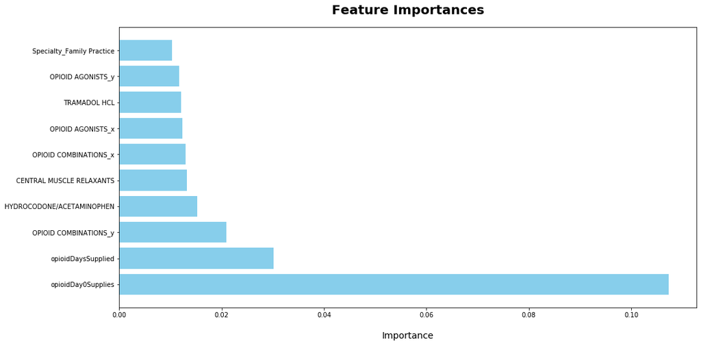

```python
# visualize the important features
dset = pd.DataFrame()
dset['attr'] = X.columns
dset['importance'] = model.feature_importances_
dset = dset.sort_values(by='importance', ascending=False)
dplot = dset.head(10)

plt.figure(figsize=(16, 8))
plt.barh(y=dplot['attr'], width=dplot['importance'], color='SkyBlue')
plt.title('Feature Importances', fontsize=20, fontweight='bold', pad=20)
plt.xlabel('Importance', fontsize=14, labelpad=20)
plt.show()
```

Nearly all of the important features are in opioid data, which totally makes sense because this category is most related to LTOT. Patients' behavior in the future highly depends on their historical opioid usage.

# 6. Predictive Modeling

## 6.1 Feature Scaling

Feature scaling basically helps to normalise the data within a particular range.It also helps in speeding up the calculations in logistic algorithm.

```python
allData = pd.concat([trainDf.drop(['LTOP'], axis=1).set_index('id'), testDf.set_index('id')], axis=0)
```

```python
from sklearn.preprocessing import StandardScaler

scaler = StandardScaler()
allData = pd.DataFrame(scaler.fit_transform(allData), columns=allData.columns)
```

```python
X = allData.iloc[:13997, ]
X_testDf = allData.iloc[13997:, ]

y = trainDf.LTOP
```

## 6.2 Model Tuning

In the modeling process, we tried three algorithms: Logistic Regression, Random Forest, and Light Gradient Boosting. We used 10-fold cross-validation, and the AUC score to tune and evaluate our models.

```python
from sklearn.model_selection import train_test_split

X_train, X_test, y_train, y_test = train_test_split(
    X, y, test_size=0.2, random_state=2019)
```

```python
from sklearn.metrics import confusion_matrix, classification_report, accuracy_score, roc_curve, auc, roc_auc_score
from sklearn.model_selection import KFold, cross_val_score
```

The following function is to get model performance report.

```python
def getAccuracy(model, threshold):

    model.fit(X_train, y_train)
    probs = model.predict_proba(X_test)[:, 1]
    y_pred = np.where(probs >= threshold, 1, 0)

    print("Confusion Matrix:\n", confusion_matrix(y_test, y_pred))
    print("\n")
    print("Classification Report:\n",classification_report(y_test, y_pred))
    return accuracy_score(y_test, y_pred)

### 10-Fold Cross Validation

n_folds = 10

def cv_ROC_AUC(model):
    """
    Return the average AUC score.
    """
    # Set KFold to shuffle data before the split
    kf = KFold(n_folds, shuffle=True, random_state=42)

    # Get accuracy score
    roc_auc = cross_val_score(model, X, y, scoring="roc_auc", cv=kf)

    return roc_auc.mean()

def get_ROC_AUC(model):
    """
    Return AUC score
    """
    model.fit(X_train, y_train)
    probs = model.predict_proba(X_test)[:,1]
    roc_auc = roc_auc_score(y_test, probs)
    return roc_auc

def plotROC(model):
    """
    1. Plot ROC AUC
    2. Return the best threshold
    """
    model.fit(X_train, y_train)
    probs = model.predict_proba(X_test)
    preds = probs[:,1]
    fpr, tpr, threshold = roc_curve(y_test, preds)
    roc_auc = auc(fpr, tpr)

    # Plot ROC AUC
    plt.title('Receiver Operating Characteristic')
    plt.plot(fpr, tpr, 'b', label = 'AUC = %0.2f' % roc_auc)
    plt.legend(loc = 'lower right')
    plt.plot([0, 1], [0, 1],'r--')
    plt.xlim([0, 1])
    plt.ylim([0, 1])
    plt.ylabel('True Positive Rate')
    plt.xlabel('False Positive Rate')
    plt.show()

    # Find optimal threshold
    rocDf = pd.DataFrame({'fpr': fpr, 'tpr':tpr, 'threshold':threshold})
    rocDf['tpr - fpr'] = rocDf.tpr - rocDf.fpr
    optimalThreshold = rocDf.threshold[rocDf['tpr - fpr'].idxmax()]

    return optimalThreshold

def evaluate(model):
    optimalThreshold = plotROC(model)
    print("Optimal Threshold: ", optimalThreshold)
    print("\n")
    print("Accuracy: ", getAccuracy(model, optimalThreshold))
```

### 6.2.1 Random Forest

```python
from sklearn.ensemble import RandomForestClassifier
```

```python
rfc = RandomForestClassifier(n_estimators=1000)
print("AUC score: ", get_ROC_AUC(rfc))
```

```
AUC score:  0.8634249288896381
```

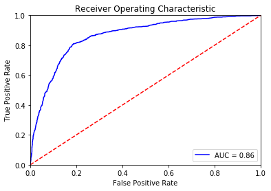

```
Optimal Threshold:  0.53


Confusion Matrix:
 [[1290  304]
 [ 241  965]]


Classification Report:
               precision    recall  f1-score   support

         0.0       0.84      0.81      0.83      1594
         1.0       0.76      0.80      0.78      1206

    accuracy                           0.81      2800
   macro avg       0.80      0.80      0.80      2800
weighted avg       0.81      0.81      0.81      2800

Accuracy:  0.8053571428571429
```

```python
evaluate(rfc)
```

### 6.2.2 Logistic Regression

```python
from sklearn.linear_model import LogisticRegression
```

```python
logit = LogisticRegression(penalty='l1', C=0.5, max_iter=1000)
print("AUC score: ", get_ROC_AUC(logit))
```

```
AUC score:  0.8510391372289535
```

```python
evaluate(logit)
```

[output not shown]

### 6.2.3 LightGBM

```python
from lightgbm import LGBMClassifier
```

```
Parameter:  500 	AUC score:  0.8720746955311272
Parameter:  1000 	AUC score:  0.8721745725575386
Parameter:  1500 	AUC score:  0.8708231115439115
```

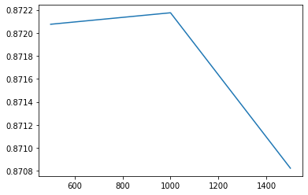

```python
# Model tuning
paraList = [500, 1000, 1500]
roc_auc_list = []

for i in paraList:
    lgb = LGBMClassifier(objective='binary',
                         learning_rate=0.049,
                         n_estimators=i, # 1462
                         num_leaves=8,
                         min_data_in_leaf=4,
                         max_depth=3,
                         max_bin=41,
                         bagging_fraction=0.845,
                         bagging_freq=5,
                         feature_fraction=0.24,
                         feature_fraction_seed=9,
                         bagging_seed=9,
                         min_sum_hessian_in_leaf=11)
    roc_auc = get_ROC_AUC(lgb)
    roc_auc_list.append(roc_auc)
    print("Parameter: ", i, "\tAUC score: ", roc_auc)

plt.plot(np.array(paraList),
         np.array(roc_auc_list))
```

```python
# Best model chosen after tuning
lgb = LGBMClassifier(objective='binary',
                        learning_rate=0.03,
                        n_estimators=1130,
                        num_leaves=8,
                        min_data_in_leaf=1,
                        max_depth=10,
                        max_bin=80,
                        bagging_fraction=0.8,
                        bagging_freq=5,
                        feature_fraction=0.24,
                        feature_fraction_seed=9,
                        bagging_seed=9,
                        min_sum_hessian_in_leaf=12)
cv_ROC_AUC(lgb)
```

```
0.8742379605162984
```

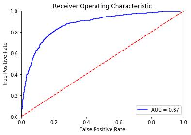

```
Optimal Threshold:  0.42789436774532463


Confusion Matrix:
 [[1248  346]
 [ 209  997]]


Classification Report:
               precision    recall  f1-score   support

         0.0       0.86      0.78      0.82      1594
         1.0       0.74      0.83      0.78      1206

    accuracy                           0.80      2800
   macro avg       0.80      0.80      0.80      2800
weighted avg       0.81      0.80      0.80      2800

Accuracy:  0.8017857142857143
```

```python
evaluate(lgb)
```

# 7. Prediction Result

We choose the LightGBM as the final model.

```python
# Use test data to make predictions
lgb.fit(X, y)
predictions = lgb.predict_proba(X_testDf)[:, 1]
```

```python
output = pd.DataFrame({'ID': testDf.id,
                       'SCORE': predictions})

testID.columns = ['ID']
output = output.merge(testID, on='ID', how='outer').fillna(0)
output['RANK'] = output.SCORE.rank(method='min', ascending=False)
output = output.sort_values('SCORE', ascending=False)
output.head(10)
```

|  | ID | SCORE | RANK |
| --- | --- | --- | --- |
| 211 | ID13059403613 | 0.953885 | 1.0 |
| 4933 | ID84350276870 | 0.925189 | 2.0 |
| 1804 | ID37816504592 | 0.919378 | 3.0 |
| 5250 | ID89243402327 | 0.910947 | 4.0 |
| 596 | ID18840549848 | 0.900573 | 5.0 |
| 2754 | ID52077569324 | 0.896590 | 6.0 |
| 738 | ID21121369358 | 0.894360 | 7.0 |
| 1967 | ID39971103398 | 0.881416 | 8.0 |
| 5604 | ID94472977563 | 0.873317 | 9.0 |
| 631 | ID19417278617 | 0.872499 | 10.0 |

```python
pd.Series(np.where(output.SCORE >= 0.5, 1, 0)).value_counts()
```

```
0    5334
1     666
dtype: int64
```

```python
y.value_counts()
```

```
0.0    7670
1.0    6327
Name: LTOP, dtype: int64
```